# Why you should stop predicting customer churn and start using uplift models - ScienceDirect

#### 4.3.3. Similarity in ranking

Table 3. Spearman’s rank order correlation and Kendall’s tau, scenario 1.

|  | Scenario 1 - Spearman’s rank order correlation CCP Log Reg | Scenario 1 - Spearman’s rank order correlation CCP RF | Scenario 1 - Spearman’s rank order correlation CCU Log Reg | Scenario 1 - Spearman’s rank order correlation CCU RF | Scenario 1 - Kendall’s tau CCP Log Reg | Scenario 1 - Kendall’s tau CCP RF | Scenario 1 - Kendall’s tau CCU Log Reg | Scenario 1 - Kendall’s tau CCU RF |
| --- | --- | --- | --- | --- | --- | --- | --- | --- |
| CCP Log Reg | 1 | 0.46 | 0.52 | 0.31 | 1 | 0.32 | 0.39 | 0.21 |
| CCP RF | 0.46 | 1 | 0.23 | 0.52 | 0.32 | 1 | 0.15 | 0.37 |
| CCU Log Reg | 0.52 | 0.23 | 1 | 0.39 | 0.39 | 0.15 | 1 | 0.27 |
| CCU RF | 0.31 | 0.52 | 0.39 | 1 | 0.21 | 0.37 | 0.27 | 1 |

Table 4. Spearman’s rank order correlation and Kendall’s tau, scenario 2.

|  | Scenario 2 - Spearman’s rank order correlation CCP Log Reg | Scenario 2 - Spearman’s rank order correlation CCP RF | Scenario 2 - Spearman’s rank order correlation CCU Log Reg | Scenario 2 - Spearman’s rank order correlation CCU RF | Scenario 2 - Kendall’s tau CCP Log Reg | Scenario 2 - Kendall’s tau CCP RF | Scenario 2 - Kendall’s tau CCU Log Reg | Scenario 2 - Kendall’s tau CCU RF |
| --- | --- | --- | --- | --- | --- | --- | --- | --- |
| CCP Log Reg | 1 | 0.47 | 0.59 | 0.17 | 1 | 0.32 | 0.44 | 0.12 |
| CCP RF | 0.47 | 1 | 0.24 | 0.35 | 0.32 | 1 | 0.16 | 0.25 |
| CCU Log Reg | 0.59 | 0.24 | 1 | 0.35 | 0.44 | 0.16 | 1 | 0.24 |
| CCU RF | 0.17 | 0.35 | 0.35 | 1 | 0.12 | 0.25 | 0.24 | 1 |

The results of the previous analysis regarding the similarities in the rankings of customers are confirmed by considering the proportions, referred to as overlap, of the same customers selected by various models at a certain cutoff *α*. Fig. 11 shows the overlap between various techniques and methodologies. In the first scenario, both the logistic regression and random forest models exhibit an overlap of 55% and 46% at $α=5%$ for the CCP and CCU settings, respectively (Fig. 11a). When comparing logistic regression and random forest models for each setting, we observe a lower overlap of 30% and 38% at $α=5%,$ respectively (Fig. 11b), confirming the significantly different selections of targeted customers resulting from different models. In the second scenario, logistic regression models exhibit a 52% overlap between the CCP and CCU setups at the cutoff of $α=5%$. The largest difference is observed between the random forest models in the CCP and CCU setups with an overlap of 21% at $α=5%$ (Fig. 11c). Finally, Fig. 11d shows overlaps of 31% and 29% at $α=5%$ for both CCP models and for both CCU models, respectively. This indicates a significant difference between the rankings in a comparison of logistic regression and random forest models for either CCP or CCU.

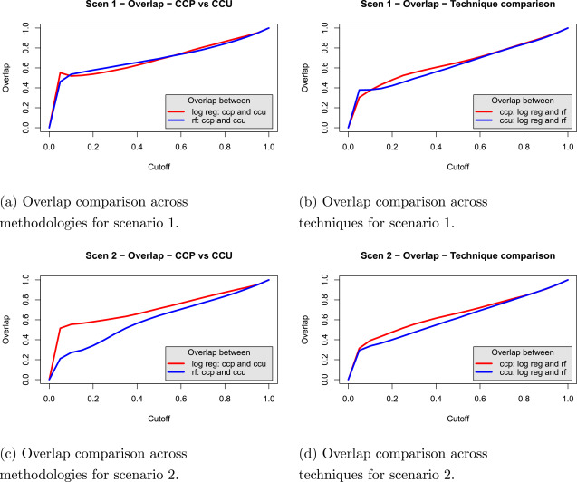

1. [Download : Download high-res image (791KB)](https://ars.els-cdn.com/content/image/1-s2.0-S0020025519312022-gr11_lrg.jpg)
2. [Download : Download full-size image](https://ars.els-cdn.com/content/image/1-s2.0-S0020025519312022-gr11.jpg)

Fig. 11. Overlap in customers observed when comparing different cutoffs of the ranking of setups (11a and 11c) and techniques (11b and 11d) for scenarios 1 and 2.

In previous studies of uplift modeling, performance of uplift models has been reported to be unstable, i.e., to vary significantly across test folds in an n-fold cross validation setup [14]. Therefore, the experiments discussed above were repeated five times to assess the impact of randomly splitting the dataset into training and test sets. The results obtained in the five repetitions and reported above were observed to be very stable, which supports the validity of the presented findings.

## 5. Conclusions and directions for future research

Prescriptive analytics, and more specifically uplift modeling, have been proposed as a paradigm that improves predictive analytics. However, no empirical evidence of uplift models outperforming predictive models has been presented in the literature. No comparative studies have been performed, and an indirect comparison based on the performance of predictive models reported in empirical studies of predictive modeling and the performance of uplift models reported in the literature is prevented by the use of different evaluation measures used to evaluate both types of models. In uplift modeling, the predicted outcome is not observed, hence the need for alternative evaluation measures that can be used to evaluate uplift models compared to predictive models. Of course, predictive models can be evaluated in terms of the uplift they achieve, whereas uplift models can be evaluated in terms of their ability to predict. However, since the above would entail evaluating a model in terms of an evaluation measure that is inconsistent with the objective adopted in learning the model, such comparisons seem unfair and inappropriate. Therefore, in this article we adopt a profit-driven evaluation approach that aligns the evaluation of analytical models with their business objective. Specifically, we focus on the use of analytics to support customer churn retention efforts, which is a standard marketing analytics application in the industry.

We introduce a novel, profit-driven evaluation measure called the maximum profit uplift measure for assessing the performance of customer churn uplift models. The proposed MPU measure extends the maximum profit measure for customer churn prediction models and allows assessing the performance of a customer churn uplift model in terms of profit per customer in the customer base that is earned when targeting the optimal proportion of customers with the highest uplift scores by a retention campaign. The optimal proportion of customers to be targeted is determined by maximizing the profit generated by the retention campaign, which is shown in this article to be directly related to the ability of the uplift model to identify the so-called persuadables, i.e., customers who are about to churn who will be retained if targeted by the campaign.

The MP measure for customer churn prediction is directly related to the ability of a predictive model to predict customer churn, as represented by the lift that is a function of the proportion of targeted customers. To define the MPU measure, we introduce the equivalent liftup measure that is a function of the proportion of targeted customers and expresses the uplift achieved at a certain cutoff relative to the overall baseline uplift achieved when targeting all customers. The introduction of the liftup measure is a genuine contribution of this article, and presents a generally applicable evaluation approach to assessing the use of an uplift model. The liftup is shown to be directly related to profit, and therefore, as argued by Neslin et al. [18], is an appropriate approach to evaluation. If liftup is used in the profit formula for retention campaigns, it becomes clear that the assumption of a constant retention rate in the profit formula adopted by the MP measure is inappropriate for evaluating either a CCU model or a CCP model, as shown in the empirical part of the study.

This article presents the results of a real-life case study in the financial industry. An experimental study was developed and performed to assess the added value of prescriptive (i.e., uplift modeling) over predictive analytics. The results indicate that customer churn uplift models outperform customer churn prediction models. Uplift models effectively appear to be able to identify the so-called persuadables and therefore yield higher returns than do customer churn prediction models. CCP models seem to assign the highest rank and thus lead to the selection of lost causes, i.e., customers who are about to churn but will not be retained if targeted by the retention campaign. These results strongly imply that uplift modeling is a superior paradigm to predictive modeling in the context of supporting customer retention efforts and likely beyond.

Future studies will focus on generalizing the newly introduced MPU measure to facilitate its adoption in different fields, as there is a need for powerful, application-oriented evaluation measures for assessing the performance of uplift models. This study also opens doors to the development of profit-driven uplift modeling approaches that aim at maximizing profitability. Finally, further empirical evidence—obtained by examining a broader variety of application types—of the added value of uplift versus predictive modeling is necessary to validate the findings of this paper.

## Declarations of Competing Interest

The authors declare that they have no known competing financial interests or personal relationships that could have appeared to influence the work reported in this paper.

## References

**[1]**

B. Baesens**Analytics in a Big Data World: The Essential Guide to Data Science and its Applications**

John Wiley & Sons (2014)

[Google Scholar](https://scholar.google.com/scholar_lookup?title=Analytics%20in%20a%20Big%20Data%20World%3A%20The%20Essential%20Guide%20to%20Data%20Science%20and%20its%20Applications&publication_year=2014&author=B.%20Baesens)

**[2]**

S. Lessmann, B. Baesens, H.-V. Seow, L.C. Thomas**Benchmarking state-of-the-art classification algorithms for credit scoring: an update of research**

Eur. J. Oper. Res., 247 (1) (2015), pp. 124-136

[Article](https://www.sciencedirect.com/science/article/pii/S0377221715004208)[Download PDF](https://www.sciencedirect.com/science/article/pii/S0377221715004208/pdfft?md5=4e3729c31cffc941d8e0d397cb93bbde&pid=1-s2.0-S0377221715004208-main.pdf)[View Record in Scopus](https://www.scopus.com/inward/record.url?eid=2-s2.0-84937523151&partnerID=10&rel=R3.0.0)Google Scholar

**[3]**

B. Baesens, V. Van Vlasselaer, W. Verbeke**Fraud Analytics Using Descriptive, Predictive, and Social Network Techniques: A Guide to Data Science for Fraud Detection**

John Wiley & Sons (2015)

Google Scholar

**[4]**

K. Coussement, K.W. De Bock**Customer churn prediction in the online gambling industry: the beneficial effect of ensemble learning**

J. Bus. Res., 66 (9) (2013), pp. 1629-1636

[Article](https://www.sciencedirect.com/science/article/pii/S0148296312003530)[Download PDF](https://www.sciencedirect.com/science/article/pii/S0148296312003530/pdfft?md5=79f48639a8024c302beffef712407c48&pid=1-s2.0-S0148296312003530-main.pdf)[View Record in Scopus](https://www.scopus.com/inward/record.url?eid=2-s2.0-84878129482&partnerID=10&rel=R3.0.0)Google Scholar

**[5]**

W. Verbeke, B. Baesens, C. Bravo**Profit Driven Business Analytics: A Practitioner’s Guide to Transforming Big Data into Added Value**

John Wiley & Sons (2017)

[Google Scholar](https://scholar.google.com/scholar?q=Profit%20Driven%20Business%20Analytics:%20A%20Practitioners%20Guide%20to%20Transforming%20Big%20Data%20into%20Added%20Value)

**[6]**

W. Verbeke, D. Martens, C. Mues, B. Baesens**Building comprehensible customer churn prediction models with advanced rule induction techniques**

Expert Syst. Appl., 38 (3) (2011), pp. 2354-2364

[Article](https://www.sciencedirect.com/science/article/pii/S0957417410008067)[Download PDF](https://www.sciencedirect.com/science/article/pii/S0957417410008067/pdfft?md5=8f822ad3f57421357b364a44cd122b30&pid=1-s2.0-S0957417410008067-main.pdf)[View Record in Scopus](https://www.scopus.com/inward/record.url?eid=2-s2.0-78049530278&partnerID=10&rel=R3.0.0)Google Scholar

**[7]**

M.R. Colgate, P.J. Danaher**Implementing a customer relationship strategy: the asymmetric impact of poor versus excellent execution**

J. Acad. Mark. Sci., 28 (3) (2000), pp. 375-387, 10.1177/0092070300283006

[CrossRef](https://doi.org/10.1177/0092070300283006)[View Record in Scopus](https://www.scopus.com/inward/record.url?eid=2-s2.0-23044520403&partnerID=10&rel=R3.0.0)Google Scholar

**[8]**

J. Ganesh, M.J. Arnold, K.E. Reynolds**Understanding the customer base of service providers: an examination of the differences between switchers and stayers**

J. Mark., 64 (3) (2000), pp. 65-87, 10.1509/jmkg.64.3.65.18028

[CrossRef](https://doi.org/10.1509/jmkg.64.3.65.18028)[View Record in Scopus](https://www.scopus.com/inward/record.url?eid=2-s2.0-0034377224&partnerID=10&rel=R3.0.0)Google Scholar

**[9]**

R.T. Rust, A.J. Zahorik**Customer satisfaction, customer retention, and market share**

J. Retail., 69 (2) (1993), pp. 193-215, 10.1016/0022-4359(93)90003-2

[Article](https://www.sciencedirect.com/science/article/pii/0022435993900032)[Download PDF](https://www.sciencedirect.com/science/article/pii/0022435993900032/pdf?md5=79bc94b2d0619c94a8c0db12fbcab853&pid=1-s2.0-0022435993900032-main.pdf)[View Record in Scopus](https://www.scopus.com/inward/record.url?eid=2-s2.0-39149097400&partnerID=10&rel=R3.0.0)[Google Scholar](https://scholar.google.com/scholar_lookup?title=Customer%20satisfaction%2C%20customer%20retention%2C%20and%20market%20share&publication_year=1993&author=R.T.%20Rust&author=A.J.%20Zahorik)

**[10]**

D.V. den Poel, B. Larivière**Customer attrition analysis for financial services using proportional hazard models**

Eur. J. Oper. Res., 157 (1) (2004), pp. 196-217, 10.1016/S0377-2217(03)00069-9

Google Scholar

**[11]**

V.S.Y. Lo**The true lift model: a novel data mining approach to response modeling in database marketing**

SIGKDD Explor. Newsl., 4 (2) (2002), pp. 78-86, 10.1145/772862.772872

[CrossRef](https://doi.org/10.1145/772862.772872)[View Record in Scopus](https://www.scopus.com/inward/record.url?eid=2-s2.0-33846104594&partnerID=10&rel=R3.0.0)Google Scholar

**[12]**

N.J. Radcliffe, R. Simpson**Identifying who can be saved and who will be driven away by retention activity.**

J. Telecommun. Manag., 1 (2) (2008)

Google Scholar

**[13]**

D. Sculley, G. Holt, D. Golovin, E. Davydov, T. Phillips, D. Ebner, V. Chaudhary, M. Young, J.-F. Crespo, D. Dennison**Hidden technical debt in machine llearning systems**

C. Cortes, N.D. Lawrence, D.D. Lee, M. Sugiyama, R. Garnett (Eds.), Advances in Neural Information Processing Systems 28, Curran Associates, Inc. (2015), pp. 2503-2511

[View Record in Scopus](https://www.scopus.com/inward/record.url?eid=2-s2.0-84965107309&partnerID=10&rel=R3.0.0)Google Scholar

http://papers.nips.cc/paper/5656-hidden-technical-debt-in-machine-learning-systems.pdf.

**[14]**

F. Devriendt, D. Moldovan, W. Verbeke**A literature survey and experimental evaluation of the state-of-the-art in uplift modeling: A stepping stone toward the development of prescriptive analytics**

Big Data, 6 (1) (2018), pp. 13-41, 10.1089/big.2017.0104

[View Record in Scopus](https://www.scopus.com/inward/record.url?eid=2-s2.0-85044383243&partnerID=10&rel=R3.0.0)Google Scholar

PMID: 29570415.

**[15]**

E. Ascarza**Retention futility: targeting high-risk customers might be ineffective**

J. Mark. Res., 55 (1) (2018), pp. 80-98, 10.1509/jmr.16.0163

[CrossRef](https://doi.org/10.1509/jmr.16.0163)[View Record in Scopus](https://www.scopus.com/inward/record.url?eid=2-s2.0-85044060586&partnerID=10&rel=R3.0.0)[Google Scholar](https://scholar.google.com/scholar_lookup?title=Retention%20futility%3A%20targeting%20high-risk%20customers%20might%20be%20ineffective&publication_year=2018&author=E.%20Ascarza)

**[16]**

N.J. Radcliffe**Using control groups to target on predicted lift: building and assessing uplift models**

Direct Mark. J. Direct. Mark. Assoc. Anal. Council., 1 (2007), pp. 14-21

[View Record in Scopus](https://www.scopus.com/inward/record.url?eid=2-s2.0-79951730601&partnerID=10&rel=R3.0.0)[Google Scholar](https://scholar.google.com/scholar_lookup?title=Using%20control%20groups%20to%20target%20on%20predicted%20lift%3A%20building%20and%20assessing%20uplift%20models&publication_year=2007&author=N.J.%20Radcliffe)

**[17]**

W. Verbeke, K. Dejaeger, D. Martens, J. Hur, B. Baesens**New insights into churn prediction in the telecommunication sector: a profit driven data mining approach**

Eur. J. Oper. Res., 218 (1) (2012), pp. 211-229, 10.1016/j.ejor.2011.09.031

[Article](https://www.sciencedirect.com/science/article/pii/S0377221711008599)[Download PDF](https://www.sciencedirect.com/science/article/pii/S0377221711008599/pdfft?md5=d7bef473d8613d8e0b30f776f9bb2a67&pid=1-s2.0-S0377221711008599-main.pdf)[View Record in Scopus](https://www.scopus.com/inward/record.url?eid=2-s2.0-83955164226&partnerID=10&rel=R3.0.0)Google Scholar

**[18]**

S.A. Neslin, S. Gupta, W. Kamakura, J. Lu, C.H. Mason**Defection detection: measuring and understanding the predictive accuracy of customer churn models**

J. Mark. Res., 43 (2) (2006), pp. 204-211, 10.1509/jmkr.43.2.204

[CrossRef](https://doi.org/10.1509/jmkr.43.2.204)[View Record in Scopus](https://www.scopus.com/inward/record.url?eid=2-s2.0-33744509693&partnerID=10&rel=R3.0.0)Google Scholar

**[19]**

T. Verbraken, C. Bravo, R. Weber, B. Baesens**Development and application of consumer credit scoring models using profit-based classification measures**

Eur. J. Oper. Res., 238 (2) (2014), pp. 505-513, 10.1016/j.ejor.2014.04.001

[Article](https://www.sciencedirect.com/science/article/pii/S0377221714003105)[Download PDF](https://www.sciencedirect.com/science/article/pii/S0377221714003105/pdfft?md5=39c4724aa010186de96b48bc5c55a8e6&pid=1-s2.0-S0377221714003105-main.pdf)[View Record in Scopus](https://www.scopus.com/inward/record.url?eid=2-s2.0-84901655653&partnerID=10&rel=R3.0.0)Google Scholar

**[20]**

W. Buckinx, D.V. den Poel**Customer base analysis: partial defection of behaviourally loyal clients in a non-contractual fmcg retail setting**

Eur. J. Oper. Res., 164 (1) (2005), pp. 252-268, 10.1016/j.ejor.2003.12.010

[Article](https://www.sciencedirect.com/science/article/pii/S0377221703009184)[Download PDF](https://www.sciencedirect.com/science/article/pii/S0377221703009184/pdfft?md5=e65d95412e53129834dfe66962db1e1b&pid=1-s2.0-S0377221703009184-main.pdf)[View Record in Scopus](https://www.scopus.com/inward/record.url?eid=2-s2.0-10444274107&partnerID=10&rel=R3.0.0)Google Scholar

**[21]**

P. Datta, B. Masand, D.R. Mani, B. Li**Automated cellular modeling and prediction on a large scale**

Artif. Intell. Rev., 14 (6) (2000), pp. 485-502, 10.1023/A:1006643109702

[View Record in Scopus](https://www.scopus.com/inward/record.url?eid=2-s2.0-0034457820&partnerID=10&rel=R3.0.0)Google Scholar

**[22]**

E. Lima, C. Mues, B. Baesens**Domain knowledge integration in data mining using decision tables: case studies in churn prediction**

J. Oper. Res. Soc., 60 (8) (2009), pp. 1096-1106, 10.1057/jors.2008.161

[CrossRef](https://doi.org/10.1057/jors.2008.161)[View Record in Scopus](https://www.scopus.com/inward/record.url?eid=2-s2.0-68149172842&partnerID=10&rel=R3.0.0)Google Scholar

**[23]**

Z.-Y. Chen, Z.-P. Fan, M. Sun**A hierarchical multiple kernel support vector machine for customer churn prediction using longitudinal behavioral data**

Eur. J. Oper. Res., 223 (2) (2012), pp. 461-472

[Article](https://www.sciencedirect.com/science/article/pii/S037722171200495X)[Download PDF](https://www.sciencedirect.com/science/article/pii/S037722171200495X/pdfft?md5=484a7930906f0928b309dfb78098e049&pid=1-s2.0-S037722171200495X-main.pdf)[View Record in Scopus](https://www.scopus.com/inward/record.url?eid=2-s2.0-84864609860&partnerID=10&rel=R3.0.0)Google Scholar

**[24]**

S.-Y. Hung, D.C. Yen, H.-Y. Wang**Applying data mining to telecom churn management**

Expert Syst. Appl., 31 (3) (2006), pp. 515-524, 10.1016/j.eswa.2005.09.080

[Article](https://www.sciencedirect.com/science/article/pii/S0957417405002654)[Download PDF](https://www.sciencedirect.com/science/article/pii/S0957417405002654/pdfft?md5=77918bff8d12636d8f6b9c98f4f059c6&pid=1-s2.0-S0957417405002654-main.pdf)[View Record in Scopus](https://www.scopus.com/inward/record.url?eid=2-s2.0-33744831465&partnerID=10&rel=R3.0.0)[Google Scholar](https://scholar.google.com/scholar_lookup?title=Applying%20data%20mining%20to%20telecom%20churn%20management&publication_year=2006&author=S.-Y.%20Hung&author=D.C.%20Yen&author=H.-Y.%20Wang)

**[25]**

W. Verbeke, D. Martens, B. Baesens**Social network analysis for customer churn prediction**

Appl. Soft Comput., 14 (2014), pp. 431-446

[Article](https://www.sciencedirect.com/science/article/pii/S1568494613003116)[Download PDF](https://www.sciencedirect.com/science/article/pii/S1568494613003116/pdfft?md5=2d77e3df2d0741d76928c57846e05f95&pid=1-s2.0-S1568494613003116-main.pdf)[View Record in Scopus](https://www.scopus.com/inward/record.url?eid=2-s2.0-84889092660&partnerID=10&rel=R3.0.0)[Google Scholar](https://scholar.google.com/scholar_lookup?title=Social%20network%20analysis%20for%20customer%20churn%20prediction&publication_year=2014&author=W.%20Verbeke&author=D.%20Martens&author=B.%20Baesens)

**[26]**

A. Backiel, B. Baesens, G. Claeskens**Predicting time-to-churn of prepaid mobile telephone customers using social network analysis**

J. Oper. Res. Soc., 67 (9) (2016), p. 0, 10.1057/jors.2016.8

Google Scholar

**[27]**

K. Coussement, S. Lessmann, G. Verstraeten**A comparative analysis of data preparation algorithms for customer churn prediction: a case study in the telecommunication industry**

Decis. Support Syst., 95 (2017), pp. 27-36, 10.1016/j.dss.2016.11.007

[Article](https://www.sciencedirect.com/science/article/pii/S0167923616302020)[Download PDF](https://www.sciencedirect.com/science/article/pii/S0167923616302020/pdfft?md5=6aa5fd90bba57b1dff0becbf7247f98a&pid=1-s2.0-S0167923616302020-main.pdf)[View Record in Scopus](https://www.scopus.com/inward/record.url?eid=2-s2.0-85028254431&partnerID=10&rel=R3.0.0)Google Scholar

**[28]**

D.B. Rubin**Causal inference using potential outcomes: design, modeling, decisions**

J. Am. Stat. Assoc., 100 (469) (2005), pp. 322-331

[CrossRef](https://doi.org/10.1198/016214504000001880)[View Record in Scopus](https://www.scopus.com/inward/record.url?eid=2-s2.0-14944344423&partnerID=10&rel=R3.0.0)[Google Scholar](https://scholar.google.com/scholar_lookup?title=Causal%20inference%20using%20potential%20outcomes%3A%20design%2C%20modeling%2C%20decisions&publication_year=2005&author=D.B.%20Rubin)

**[29]**

N. Radcliffe**Generating incremental sales: maximizing the incremental impact of cross-selling, up-selling and deep-selling through uplift modelling**

Stochast. Solut. Limit. (2007)

Google Scholar

**[30]**

M. Jaskowski, S. Jaroszewicz**Uplift modeling for clinical trial data**

ICML Workshop on Clinical Data Analysis (2012)

[Google Scholar](https://scholar.google.com/scholar_lookup?title=Uplift%20modeling%20for%20clinical%20trial%20data&publication_year=2012&author=M.%20Jaskowski&author=S.%20Jaroszewicz)

**[31]**

D. Porter, Pinpointing the persuadables: Convincing the right voters to support barack obama, 2012, (http://www.predictiveanalyticsworld.com/patimes/video-dan-porter-clip/). Accessed: 2016-04-12.

[Google Scholar](https://scholar.google.com/scholar?q=D.%20Porter,%20Pinpointing%20the%20persuadables:%20Convincing%20the%20right%20voters%20to%20support%20barack%20obama,%202012,%20.%20Accessed:%202016-04-12.)

**[32]**

L. Guelman, M. Guillen, A.M. Perez-Marin**Random forests for uplift modeling: an insurance customer retention case**

K.J. Engemann, A.M. Gil-Lafuente, J. Merigo (Eds.), Modeling and Simulation in Engineering, Economics and Management, Lecture Notes in Business Information Processing, 115, Springer Berlin Heidelberg (2012), pp. 123-133, 10.1007/978-3-642-30433-0_13

[CrossRef](https://doi.org/10.1007/978-3-642-30433-0_13)[View Record in Scopus](https://www.scopus.com/inward/record.url?eid=2-s2.0-84862158492&partnerID=10&rel=R3.0.0)Google Scholar

**[33]**

L. Lai, S.F.U. (Canada).**Influential Marketing: A New Direct Marketing Strategy Addressing the Existence of Voluntary Buyers**

Canadian theses on microfiche, Simon Fraser University (Canada) (2006)

Google Scholar

https://books.google.be/books?id=5EvSuAAACAAJ.

**[34]**

P.W. Holland**Statistics and causal inference**

J. Am. Stat. Assoc., 81 (396) (1986), pp. 945-960

[View Record in Scopus](https://www.scopus.com/inward/record.url?eid=2-s2.0-84920420698&partnerID=10&rel=R3.0.0)[Google Scholar](https://scholar.google.com/scholar_lookup?title=Statistics%20and%20causal%20inference&publication_year=1986&author=P.W.%20Holland)

**[35]**

K. Kane, V.S.Y. Lo, J. Zheng**True-lift modeling: comparison of methods**

J. Mark. Anal., 2 (4) (2014), pp. 218-238

[CrossRef](https://doi.org/10.1057/jma.2014.18)[View Record in Scopus](https://www.scopus.com/inward/record.url?eid=2-s2.0-85028261598&partnerID=10&rel=R3.0.0)[Google Scholar](https://scholar.google.com/scholar_lookup?title=True-lift%20modeling%3A%20comparison%20of%20methods&publication_year=2014&author=K.%20Kane&author=V.S.Y.%20Lo&author=J.%20Zheng)

**[36]**

A. Shaar, T. Abdessalem, O. Segard**Pessimistic uplift modeling**

ACM SIGKDD (2016)

[Google Scholar](https://scholar.google.com/scholar_lookup?title=Pessimistic%20uplift%20modeling&publication_year=2016&author=A.%20Shaar&author=T.%20Abdessalem&author=O.%20Segard)

10.475/123_4.

**[37]**

N.J. Radcliffe, P.D. Surry**Real-world uplift modelling with significance-based uplift trees**

White Paper TR-2011-1, Stochastic Solutions (2011)

[Google Scholar](https://scholar.google.com/scholar_lookup?title=Real-world%20uplift%20modelling%20with%20significance-based%20uplift%20trees&publication_year=2011&author=N.J.%20Radcliffe&author=P.D.%20Surry)

**[38]**

D.M. Chickering, D. Heckerman**A decision theoretic approach to targeted advertising**

Proceedings of the Sixteenth Conference on Uncertainty in Artificial Intelligence, UAI’00, Morgan Kaufmann Publishers Inc., San Francisco, CA, USA (2000), pp. 82-88

[View Record in Scopus](https://www.scopus.com/inward/record.url?eid=2-s2.0-4243049714&partnerID=10&rel=R3.0.0)[Google Scholar](https://scholar.google.com/scholar_lookup?title=A%20decision%20theoretic%20approach%20to%20targeted%20advertising&publication_year=2000&author=D.M.%20Chickering&author=D.%20Heckerman)

http://dl.acm.org/citation.cfm?id=2073946.2073957.

**[39]**

L. Breiman, J. Friedman, C.J. Stone, R.A. Olshen**Classification and regression trees**

CRC press (1984)

[Google Scholar](https://scholar.google.com/scholar_lookup?title=Classification%20and%20regression%20trees&publication_year=1984&author=L.%20Breiman&author=J.%20Friedman&author=C.J.%20Stone&author=R.A.%20Olshen)

**[40]**

G.V. Kass**An exploratory technique for investigating large quantities of categorical data**

Appl. Stat. (1980), pp. 119-127

[CrossRef](https://doi.org/10.2307/2986296)[View Record in Scopus](https://www.scopus.com/inward/record.url?eid=2-s2.0-85082682307&partnerID=10&rel=R3.0.0)[Google Scholar](https://scholar.google.com/scholar_lookup?title=An%20exploratory%20technique%20for%20investigating%20large%20quantities%20of%20categorical%20data&publication_year=1980&author=G.V.%20Kass)

**[41]**

P. Rzepakowski, S. Jaroszewicz**Decision trees for uplift modeling with single and multiple treatments**

Knowl. Inf. Syst., 32 (2) (2012), pp. 303-327, 10.1007/s10115-011-0434-0

[CrossRef](https://doi.org/10.1007/s10115-011-0434-0)[View Record in Scopus](https://www.scopus.com/inward/record.url?eid=2-s2.0-84864307155&partnerID=10&rel=R3.0.0)[Google Scholar](https://scholar.google.com/scholar_lookup?title=Decision%20trees%20for%20uplift%20modeling%20with%20single%20and%20multiple%20treatments&publication_year=2012&author=P.%20Rzepakowski&author=S.%20Jaroszewicz)

**[42]**

L. Guelman, M. Guillen, A.M. Pérez-Marín**Optimal personalized treatment rules for marketing interventions: a review of methods, a new proposal, and an insurance case study**

Working Papers, Universitat de Barcena, UB Riskcenter (2014)

Google Scholar

http://ideas.repec.org/p/bak/wpaper/201406.html.

**[43]**

B. Hansotia, B. Rukstales**Incremental value modeling**

J. Interact. Mark., 16 (3) (2001), pp. 35-46, 10.1002/dir.10035

[Google Scholar](https://scholar.google.com/scholar_lookup?title=Incremental%20value%20modeling&publication_year=2001&author=B.%20Hansotia&author=B.%20Rukstales)

**[44]**

B. Hansotia, B. Rukstales**Direct marketing for multichannel retailers: issues, challenges and solutions**

J. Database Mark., 9 (3) (2002), pp. 259-266

Google Scholar

**[45]**

T. Verbraken, W. Verbeke, B. Baesens**A novel profit maximizing metric for measuring classification performance of customer churn prediction models**

IEEE Trans. Knowl. Data Eng., 25 (5) (2013), pp. 961-973

Google Scholar

**[46]**

K. Dejaeger, W. Verbeke, D. Martens, B. Baesens**Data mining techniques for software effort estimation: a comparative study**

IEEE Trans. Softw. Eng., 38 (2) (2012), pp. 375-397, 10.1109/TSE.2011.55

Google Scholar

**[47]**

R Core Team, R: A Language and Environment for Statistical Computing, R Foundation for Statistical Computing, Vienna, Austria, 2013. [http://www.R-project.org/](http://www.r-project.org/).

Google Scholar

**[48]**

M.K.C. from Jed Wing, S. Weston, A. Williams, C. Keefer, A. Engelhardt, T. Cooper, Z. Mayer, B. Kenkel, the R Core Team, M. Benesty, R. Lescarbeau, A. Ziem, L. Scrucca, Y. Tang, C. Candan, T. Hunt., caret: Classification and Regression Training, 2018. [https://CRAN.R-project.org/package=caret](https://cran.r-project.org/package=caret) r package version 6.0–80.

Google Scholar

**[49]**

L. Guelman, uplift: Uplift Modeling, 2014. R package version 0.3.5.

[Google Scholar](https://scholar.google.com/scholar?q=L.%20Guelman,%20uplift:%20Uplift%20Modeling,%202014.%20R%20package%20version%200.3.5.)

**[50]**

L. Breiman**Random forests**

Mach. Learn., 45 (1) (2001), pp. 5-32

[Google Scholar](https://scholar.google.com/scholar_lookup?title=Random%20forests&publication_year=2001&author=L.%20Breiman)

© 2020 The Authors. Published by Elsevier Inc.

Citations

Captures